# Exploring Environmental Data (ENS-215)

Winter 2026

| [Lectures and Labs](https://stahlm.github.io/ENS_215/Winter_2026/Home.html) | [Homework](https://stahlm.github.io/ENS_215/Winter_2026/HW.html) | [Syllabus](https://stahlm.github.io/ENS_215/Winter_2026/Syllabus.html) |
| --- | --- | --- |

### Week 1

#### Readings

- [**ModernDive Ch: 1**](https://moderndive.com/v2/getting-started.html)
- [**R for Data Science (R4DS) Introduction**](https://r4ds.hadley.nz/intro)

#### Assignments

**1. Download R and RStudio:** You will first need to download R and then RStudio. To download R go to [this link](https://cran.rstudio.com/) and download R. You will see links for Mac and Windows users (*see screenshot below*). Make sure to select the appropriate one for your computer. Download the program and then install it.

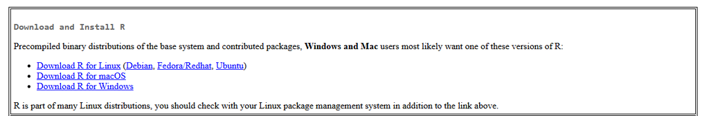

Once you’ve downloaded and installed R, then you will need to get RStudio. Go to [this link](https://posit.co/download/rstudio-desktop/) scroll down a bit and then you will see links for Mac and Windows users (*see screenshot below*). Make sure to select the appropriate one for your computer. Download and install the software.

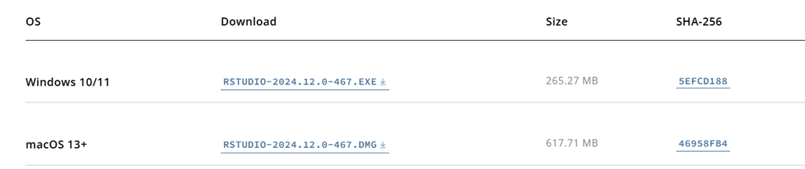

- Assigned: 6-Jan
- Due: 8-Jan

**2. Accept the invite to our DataCamp class and complete “*Introduction to R*”**  
Click the [invite link here](https://www.datacamp.com/groups/shared_links/fbb753d99d62b1fb8cb00adf9a91f785de18912a1ee0ad7c00c4d57d7b3ccc43) and join our class group. You will need to use you **union.edu** email address when creating your account.

- Assigned: 6-Jan
- Due: 8-Jan (accept invite); 13-Jan (complete “Introduction to R” assignment)
- **Note:** You should accept the DataCamp invitation immediately

**3. Get a binder to hold your course notes and bring to all future classes**

**4. Sign up for Posit (RStudio) Cloud**

You will receive an email invitation to join our Posit (RStudio) Cloud group. You should accept this invitation and create an account if you haven’t done so already.

- Assigned: 6-Jan
- Due: 8-Jan

**5. Complete course intro survey**

- [Survey link here](https://forms.gle/9xZtYcnTchHBJb6o8)
- Assigned: 6-Jan
- Due: 8-Jan

*Mason Stahl (2026)*  
*Union College*